# ResBaz 2026 Data Storytelling with R and ggplot

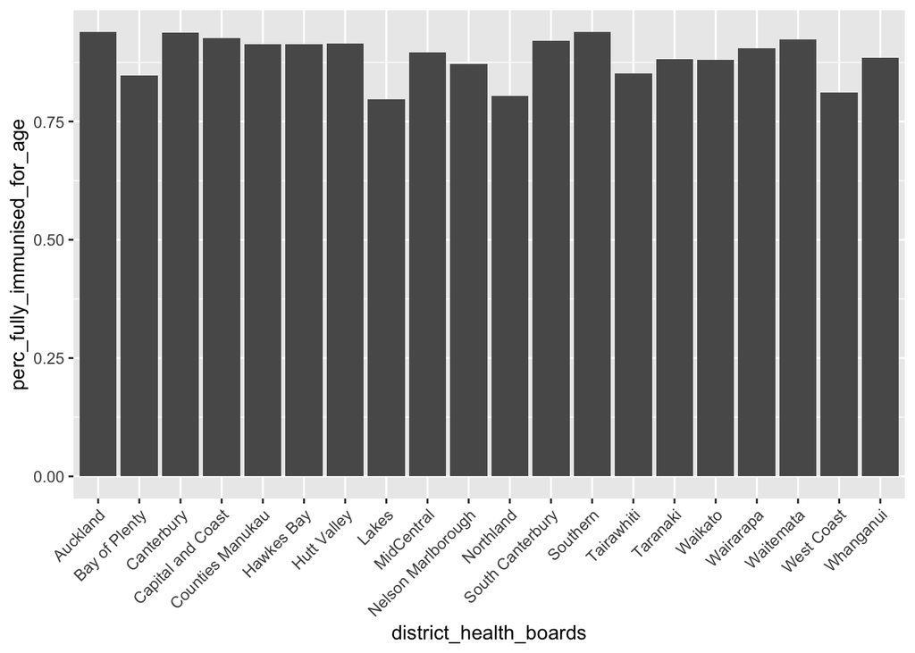

```r
ggplot(child_imm_2020_dhb,
       aes(x = district_health_boards,
           y = perc_fully_immunised_for_age)
       ) +
  geom_col() +# this adds a column plot layer
  theme(axis.text.x = element_text(angle = 45, hjust = 1))
```

Replacing the labels with plain English and adding a title will improve readability. To avoid the x-axis labels overlapping, we can rotate the labels by 45 degrees using the `theme()` function. We can also set the y-axis to go from 0% to 100%.

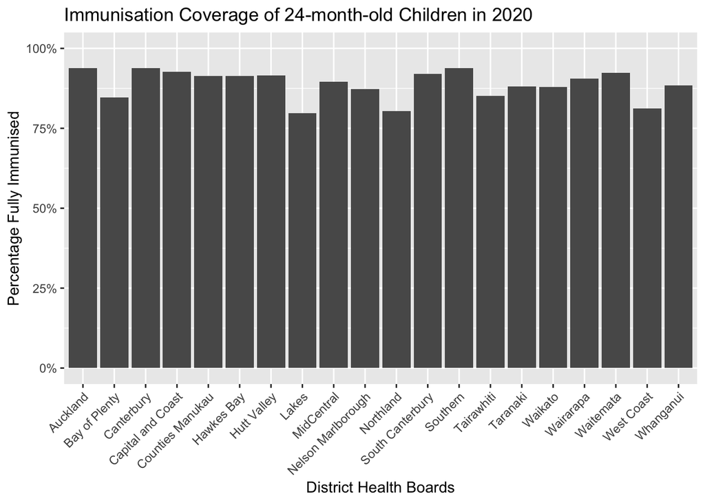

```r
ggplot(child_imm_2020_dhb,
       aes(x = district_health_boards,
           y = perc_fully_immunised_for_age)
       ) +
  geom_col() +
  # NEW LINES:
  labs(title = "Immunisation Coverage of 24-month-old Children in 2020", # title at the top of the plot
       x = "District Health Boards", # x-axis label
       y = "Percentage Fully Immunised") + # y-axis label
  scale_y_continuous(labels = scales::percent_format()) + # this line formats the y-axis labels as percentages
  coord_cartesian(ylim = c(0,1)) + # this line sets the y-axis limits to 0% to 100%
  theme(axis.text.x = element_text(angle = 45, hjust = 1)) # this rotates the x-axis labels by 45 degrees
```

Alternatively, we can place the districts on the y-axis and the immunisation coverage on the x-axis

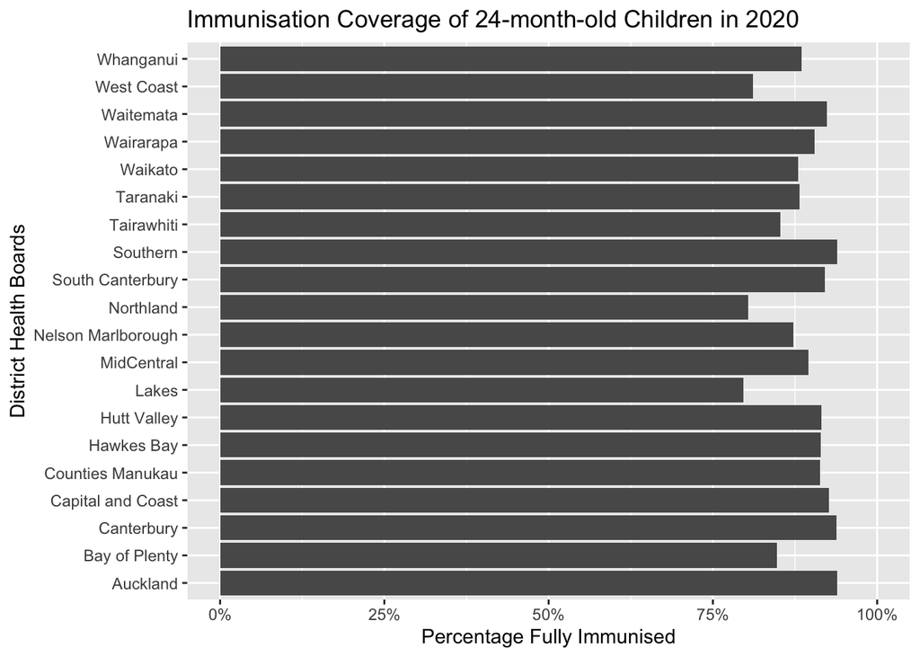

```r
ggplot(child_imm_2020_dhb,
       # NEW LINES: swapped x and y
       aes(x = perc_fully_immunised_for_age,
           y = district_health_boards)
       ) +
  geom_col() +
  # NEW LINES:
  labs(title = "Immunisation Coverage of 24-month-old Children in 2020",
       x = "Percentage Fully Immunised",
       y = "District Health Boards") +
  scale_x_continuous(labels = scales::percent_format()) +
  coord_cartesian(xlim = c(0,1))
```

You may also choose to focus on the range 75% to 100%

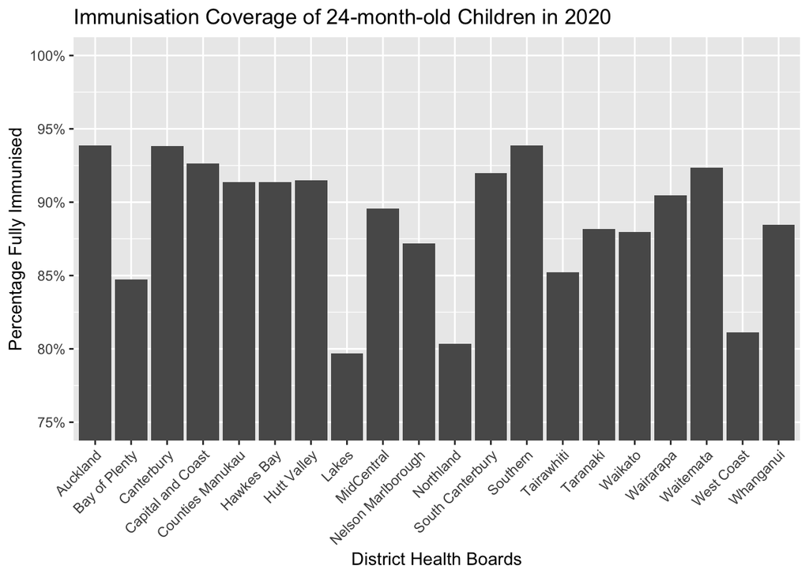

```r
ggplot(child_imm_2020_dhb,
       aes(x = district_health_boards,
           y = perc_fully_immunised_for_age)
       ) +
  geom_col() +
  labs(title = "Immunisation Coverage of 24-month-old Children in 2020",
       x = "District Health Boards",
       y = "Percentage Fully Immunised") +
  scale_y_continuous(labels = scales::percent_format()) + # this line formats the y-axis labels as percentages
  # NEW LINE:
  coord_cartesian(ylim = c(0.75,1)) + # this line sets the y-axis limits to 75% to 100%
  theme(axis.text.x = element_text(angle = 45, hjust = 1))
```

We can make the plot more informative by colouring the bars with the region. We can do this by mapping the `region` variable to the `fill` aesthetic in the `aes()` function.

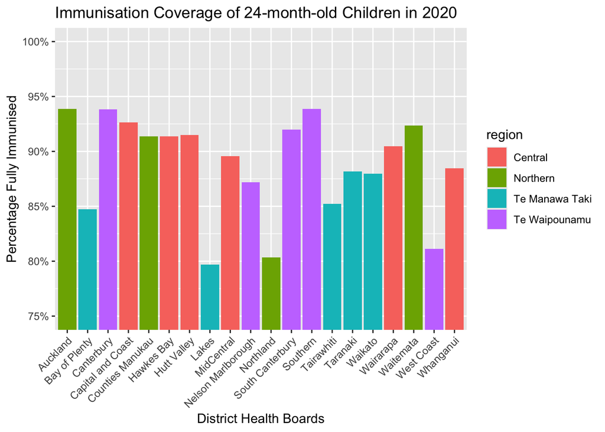

```r
ggplot(child_imm_2020_dhb,
       aes(x = district_health_boards,
           y = perc_fully_immunised_for_age,
           # NEW LINE:
           fill = region) # mapping the fill aesthetic to region
       ) +
  geom_col() +
  labs(title = "Immunisation Coverage of 24-month-old Children in 2020",
       x = "District Health Boards",
       y = "Percentage Fully Immunised") +
  scale_y_continuous(labels = scales::percent_format()) +
  coord_cartesian(ylim = c(0.75,1)) +
  theme(axis.text.x = element_text(angle = 45, hjust = 1))
```

To bring further clarity, we can order the bars in ascending order of percentage fully immunised

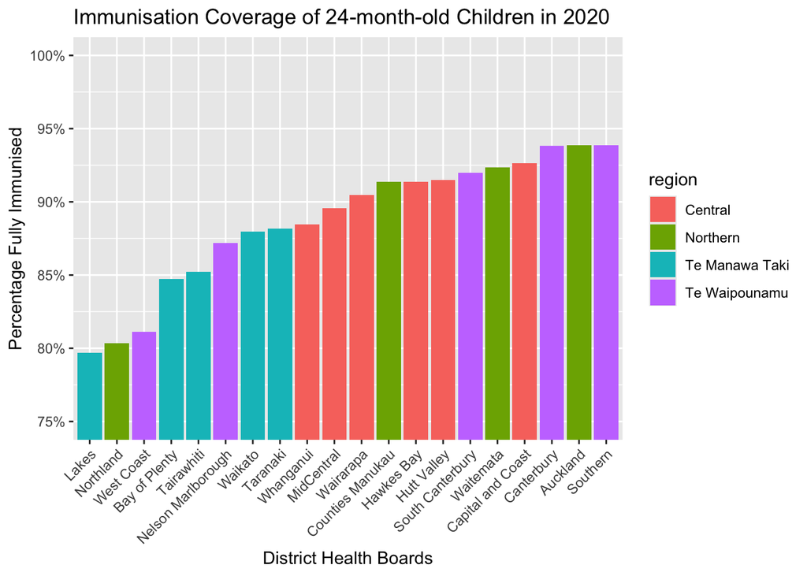

```r
ggplot(child_imm_2020_dhb,
       # NEW LINE:
       aes(x = fct_reorder(district_health_boards, perc_fully_immunised_for_age),
           y = perc_fully_immunised_for_age,
           fill = region)
       ) +
  geom_col() +
  labs(title = "Immunisation Coverage of 24-month-old Children in 2020",
       x = "District Health Boards",
       y = "Percentage Fully Immunised") +
  scale_y_continuous(labels = scales::percent_format()) +
  coord_cartesian(ylim = c(0.75,1)) +
  theme(axis.text.x = element_text(angle = 45, hjust = 1))
```

### Exercise 2

Explore data for your chosen question.

1. Filter the data
   1. (option 1) filter for the national district health board, total ethnicity
   2. (option 2) filter for the year 2026, total ethnicity
   3. (option 3) filter for the year 2026, national district health board
2. Make an scatter plot of the data (`geom_point()`)

You may also try other geometries, such as `geom_line()` or `geom_col()`, and use different aesthetics to map the data to the plot, such as `colour`, `fill`, `size`, `shape`, `linetype`, etc. (just remember to adjust the dataframe appropriately to include the correct rows and columns you want to plot).

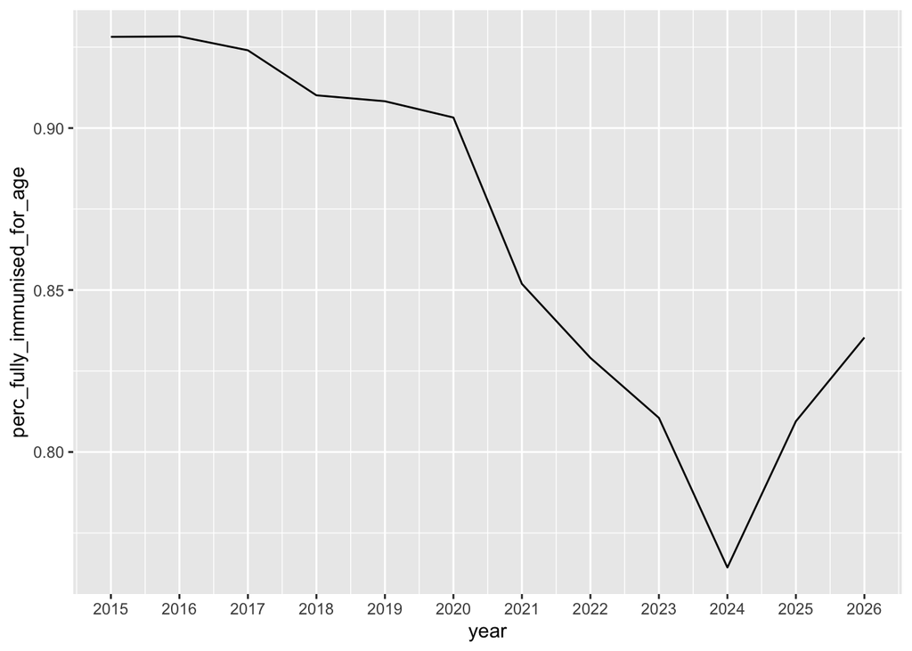

```r
# fill in the blanks below
# define a new dataframe to use for this plot
child_imm_year <- child_imm |>
  filter(
    district_health_boards == "National", # filter 1
    ethnicity == "Total" # filter 2
    )


p <- ggplot(child_imm_year, # data
       aes(x = year, # mapping x axis
           y = perc_fully_immunised_for_age) # mapping y axis
       ) +
  geom_line() + # geom layer
  scale_x_continuous(breaks=2015:2026)

print(p)
```

```r
library(plotly)
ggplotly(p)
```

[interactive chart not shown]

## Storytelling 3: characters

Pick out a few data points or patterns to focus your storytelling.

Main “characters” data points are the center of your story, they will experience conflict and resolution, and they may interact with the world or other characters in the story.

Secondary “characters” data points (rivals, antagonist, best friend) that interact with the main characters, they enhance the story and provide context or contrast to the main characters. In a graph, these could be additional data points or variables.

(option 1a) might choose to measure against the government targets 84% (by June 2025), 87% (by June 2026), and 95% (by 2030)

(option 1b) might choose to characterise the year-on-year difference and the improvements since 2024

(option 1c) might choose to include data from each region to show the differences in immunisation coverage

(option 2) might choose to characterise the Tairawhiti region, which has the second lowest immunisation coverage in 2026 but was average in 2015

(option 3) might choose to focus on Maori children, who historically had lower immunisation coverage than non-Maori children.

## Storytelling 4: message, conflict & resolution

The message is the main point you want to convey to your audience. It should be clear, concise, and supported by the data. This could be added as text in a title, subtitle, or as an annotation in the plot.

The conflict is the main point of interest in your data. This could be a trend (e.g. general growth), a pattern (e.g. sudden drop), or a specific data point (e.g. anomaly) that stands out. It should be something that captures the attention of the audience and makes them want to learn more.

The resolution is the conclusion or insight, such as additional data that gives more insights to the conflict, or actionable insights.

### Exercise 3

Choose something to highlight within your data.

1. In one sentence, summarise the message you want to convey. Make this your title or subtitle.
2. Enhance and build upon your previous plot to support this message with your graph. You can use the `annotate()` function to add text `annotate("text",...)` or arrows `annotate("segement",...)` to your plot to highlight specific data points or patterns. Adding additional geometries with colour and other aesthetics can also help to you focus the attention of the reader.

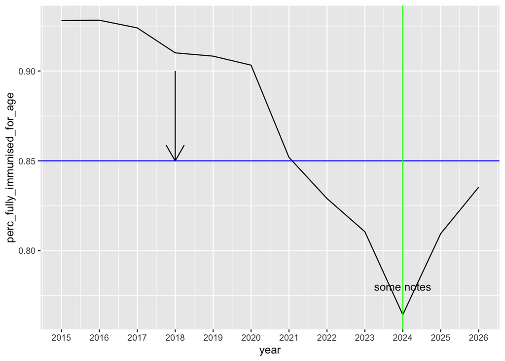

```r
# fill in the blanks below
# define a new dataframe to use for this plot
child_imm_year <- child_imm |>
  filter(
    district_health_boards == "National", # filter 1
    ethnicity == "Total" # filter 2
    )


ggplot(child_imm_year, # data
       aes(x = year, # mapping x axis
           y = perc_fully_immunised_for_age) # mapping y axis
       ) +
  geom_line() + # geom layer
  annotate("segment",
           x = 2018, xend = 2018,
           y = 0.9, yend = 0.85,
           arrow = arrow()) +
  annotate("text",
           x = 2024,
           y = 0.78,
           label = "some notes") +
  geom_hline(aes(yintercept = 0.85),
             colour="blue"
             ) +
  geom_vline(aes(xintercept = 2024), colour = "green") +
  scale_x_continuous(breaks=2015:2026)
```

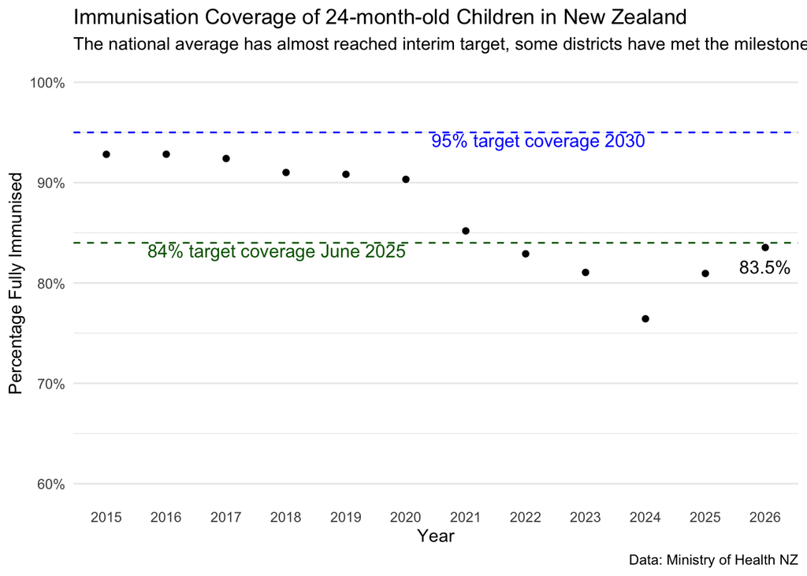

```r
# write your answer here
# write your answer here
child_imm_year <- child_imm |>
  filter(district_health_boards == "National",
         ethnicity == "Total")

perc_2026 = child_imm_year |> filter(year == 2026) |> pull(perc_fully_immunised_for_age)

ggplot(child_imm_year,
       aes(x = year, y = perc_fully_immunised_for_age)
       ) +
  geom_point() +

  geom_hline(yintercept = 0.95, linetype = "dashed", color = "blue") +
  annotate("text",
           x = 2024, y = 0.95,
           label = "95% target coverage 2030",
           colour = "blue",
           hjust = 1, vjust = 1.1, size = 4) +
  geom_hline(yintercept = 0.84, linetype = "dashed", color = "darkgreen") +
  annotate("text",
           x = 2020, y = 0.84,
           label = "84% target coverage June 2025",
           colour = "darkgreen",
           hjust = 1, vjust = 1.1, size = 4) +
  annotate("text",
           x = 2026, y = perc_2026,
           label = paste0(round(perc_2026*100,1), "%"),
           colour = "black",
           hjust = 0.5, vjust = 2, size = 4) +
  scale_x_continuous(breaks = seq(2015, 2026, 1)) +
  scale_y_continuous(labels = scales::percent_format(), limits = c(0.6,1)) +
  labs(title = "Immunisation Coverage of 24-month-old Children in New Zealand",
       subtitle = "The national average has almost reached interim target, some districts have met the milestone",
       x = "Year",
       y = "Percentage Fully Immunised",
       caption = "Data: Ministry of Health NZ") +
  theme_minimal() +
  theme(legend.position = "none", # remove the legend
        panel.grid.major.x = element_blank(), # remove x axis grid lines
        panel.grid.minor.x = element_blank())
```

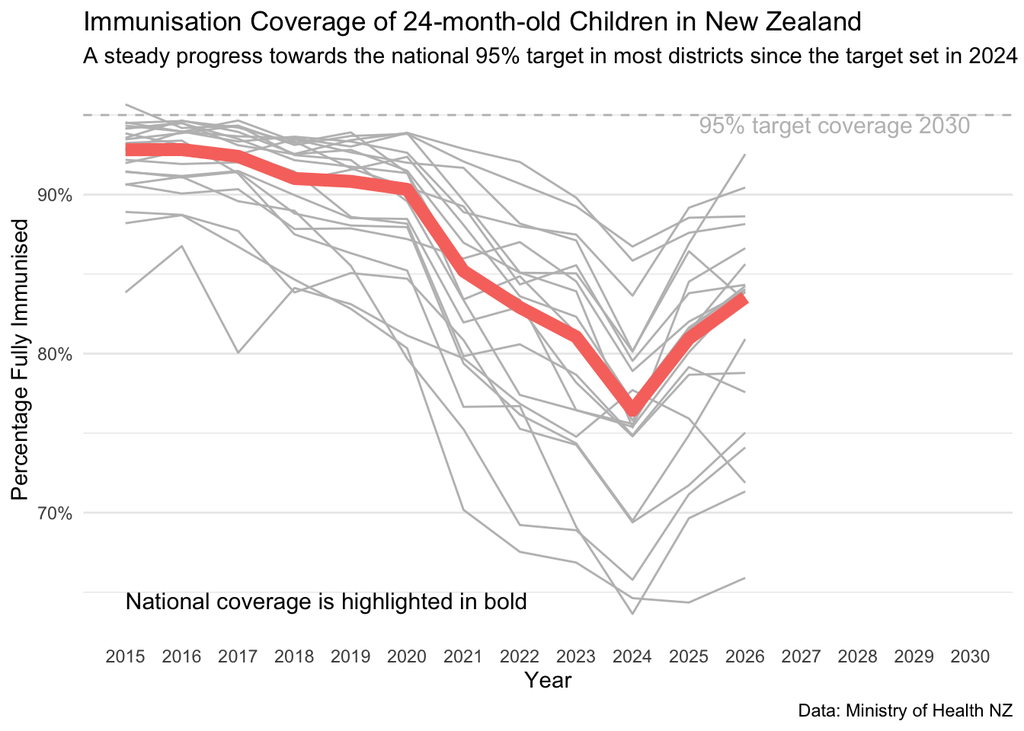

```r
# write your answer here
child_imm_year <- child_imm |>
  filter( ethnicity == "Total")

ggplot(child_imm_year,
       aes(x = year, y = perc_fully_immunised_for_age, colour = district_health_boards)
       ) +
  geom_line(aes(group = district_health_boards), colour = "grey") +
  geom_line(data=child_imm_year|>filter(district_health_boards=="National"),
            # aes(x = year, y = perc_fully_immunised_for_age), # this line is not needed as we are using the same aes() as the main plot
            linewidth=3) +
  annotate("text",
           x = 2015, y = 0.65,
           label = "National coverage is highlighted in bold",
           hjust = 0, vjust = 1, size = 4) +
  geom_hline(yintercept = 0.95, linetype = "dashed", color = "grey") +
  annotate("text",
           x = 2030, y = 0.95,
           label = "95% target coverage 2030",
           colour = "grey",
           hjust = 1, vjust = 1.1, size = 4) +
  scale_x_continuous(breaks = seq(2015, 2030, 1), limits = c(2015,2030)) +
  scale_y_continuous(labels = scales::percent_format()) +
  labs(title = "Immunisation Coverage of 24-month-old Children in New Zealand",
      subtitle = "A steady progress towards the national 95% target in most districts since the target set in 2024",
       x = "Year",
       y = "Percentage Fully Immunised",
       caption = "Data: Ministry of Health NZ") +
  theme_minimal() +
  theme(legend.position = "none", # remove the legend
        panel.grid.major.x = element_blank(), # remove x axis grid lines
        panel.grid.minor.x = element_blank())
```

```
## `geom_line()`: Each group consists of only one observation.
## ℹ Do you need to adjust the group aesthetic?
## `geom_line()`: Each group consists of only one observation.
## ℹ Do you need to adjust the group aesthetic?
```

[figure not shown]

```r
child_imm_year <- child_imm |>
  filter(ethnicity == "Total") |>
  group_by(year) |>
  mutate(rank_desc = min_rank(desc(perc_fully_immunised_for_age))) |>
  ungroup() |>
  filter(district_health_boards %in% c("National", "Tairawhiti"))

library(gganimate)

ggplot(child_imm_year,
       aes(x = year, y = perc_fully_immunised_for_age, colour = district_health_boards)
       ) +
  geom_line() +
  scale_x_continuous(breaks = seq(2015, 2026, 1), limits = c(2015,2026.5)) +
  scale_y_continuous(labels = scales::percent_format()) +
  geom_text(data = child_imm_year |> filter(district_health_boards == "Tairawhiti"),
           aes(x = year,
               y = perc_fully_immunised_for_age,
               label = paste0("Top ", rank_desc)),
           hjust = 0, vjust = 0, size = 3) +
  labs(title = "Immunisation Coverage of 24-month-old Children in New Zealand",
       subtitle = "Tairāwhiti experienced a sharper drop in 2017-2024 than the rest of NZ",
       x = "Year",
       y = "Percentage Fully Immunised") +
  theme(legend.title=element_blank()) +
  transition_states(
    year,
    transition_length = 2,
    state_length = 1) +
  transition_reveal(year) +
  ease_aes('linear')
```